# Introduction to Malaria Modeling Skills in R & RStudio using ML Algorithms

D.K.MURIITHI

2024-08-27

## Confirmation and setting of working directory

```r
setwd("~/TMMS2024")
```

## Installation and loading of necessary packages/libraries

## Loading libraries

```r
library(caret) #for training machine learning models
library(psych) ##for description of  data
library(ggplot2) ##for data visualization
library(caretEnsemble)##enables the creation of ensemble models
library(tidyverse) ##for data manipulation
library(mlbench)  ## For benchmarking ML Models
library(flextable) ## To create and style tables
library(mltools) #for hyperparameter tuning
library(tictoc) #for determining the time taken for a model to run
library(ROSE)  ## for random oversampling
library(smotefamily) ## for smote sampling
library(ROCR) ##For ROC curve
library(pROC) ## For visualizing, smoothing, and comparing ROC curves
library(e1071) ## For statistical modeling and  machine learning tasks
library(class) ## For classification using k-Nearest Neighbors and other methods
library(caTools) ## For splitting data into training and testing sets
library(MASS) ## Provides plotting functions and datasets
library(ISLR) ## for practical applications of statistical learning methods
library(boot) ## Useful for performing bootstrap resampling
library(cvTools) ## Contains functions for cross-validation, bootstrapping, and other resampling methods
```

## Loading the given Malaria data

https://statistics.knbs.or.ke/nada/index.php/catalog/111/related-materials

```r
mdata = read.csv("final_malaria_survey_data.csv", header = TRUE)
#head(mdata)
```

## Exporatory of the dataset

```r
dim(mdata)      ## View the Dimension of the Data
```

```
[1] 3280   14
```

```r
#names(mdata)     ## View the variable/features/column names
#summary(mdata)    ## Descriptive Statistics
#describe(mdata)   ## Descriptive Statistics
#sum(is.na(mdata))  ## Check for missing data
#na.omit(mdata)     ## Remove rows with any missing values
#is.na(mdata$Malaria.Test)  ## checks for missing values in the Malaria.Test column of your data frame
```

## Note: For the purpose of this training: It is assumed that the data is already clean and preprocessed

# Factor the Target variable

```r
mdata$Malaria.Test <- as.factor(mdata$Malaria.Test)
```

# Plot Target variable using R Base function

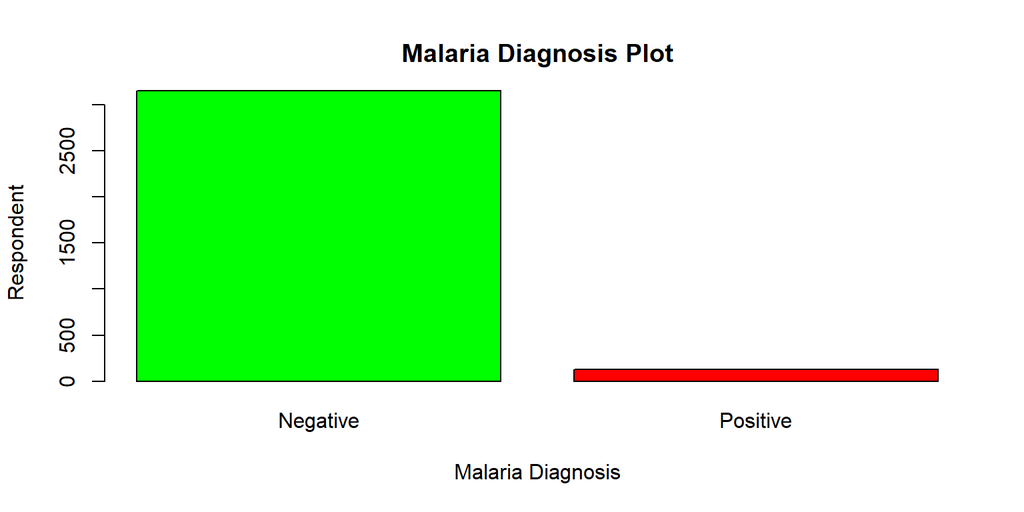

```r
plot(factor(mdata$Malaria.Test),
     names= c("Negative", "Positive"),
     col=c("green","red"),
     ylim=c(0, 3000), ylab= "Respondent", xlab= "Malaria Diagnosis", main = "Malaria Diagnosis Plot")
```

```r
#box()
```

# Plot Target variable using ggplot function

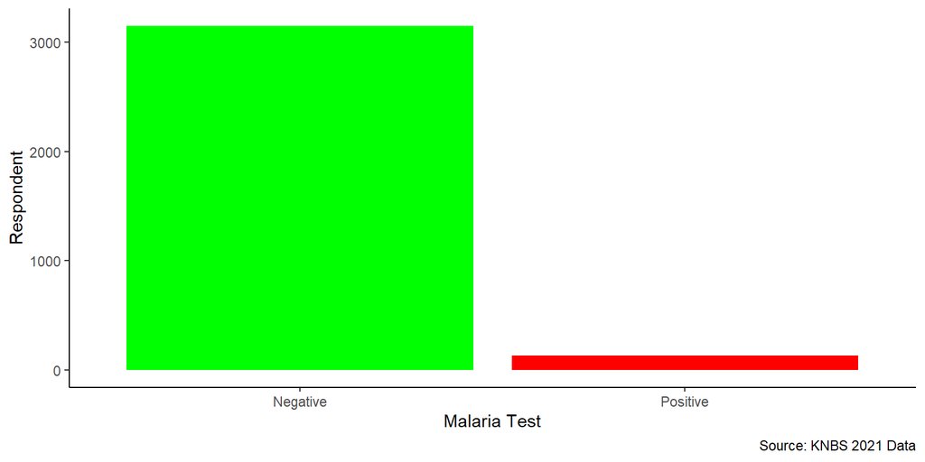

```r
ggplot(mdata, aes(x = Malaria.Test)) +
  geom_bar(fill= c("green", "red")) +
  labs(x = "Malaria Test",
       y = "Respondent",
       tittle = "Malaria Diagnosis Results",
       caption = "Source: KNBS 2021 Data") +
    theme_classic()
```

# Check for zero variance predictors:

```r
nzv <- nearZeroVar(mdata[,-14], saveMetrics = TRUE) ## Function called nearZeroVar and captures its output in the variable nzv
nzv
```

```
                                                           freqRatio
Region                                                      1.009629
County                                                      1.138462
Zones                                                       1.595461
Has.mosquito.bed.net.for.sleeping                           2.714609
Children.under.5.who.slept.under.mosquito.net.last.night    1.952435
Number.of.Mosquito.bed.nets                                 1.009060
Number.of.children.under.mosquito.bed.nets.last.night       1.078100
Anaemia.Level                                               1.883333
Mothers.highest.educational.level                           1.700673
The.type.of.mosquito.net.the.person.slept.under.last.night  1.169383
Presence.of.species..Falciparum                             9.061350
Presence.of.species..Malariae                               9.412698
Presence.of.species..Ovale                                 19.628931
                                                           percentUnique
Region                                                        0.24390244
County                                                        1.43292683
Zones                                                         0.15243902
Has.mosquito.bed.net.for.sleeping                             0.06097561
Children.under.5.who.slept.under.mosquito.net.last.night      0.12195122
Number.of.Mosquito.bed.nets                                   0.24390244
Number.of.children.under.mosquito.bed.nets.last.night         0.15243902
Anaemia.Level                                                 0.12195122
Mothers.highest.educational.level                             0.12195122
The.type.of.mosquito.net.the.person.slept.under.last.night    0.12195122
Presence.of.species..Falciparum                               0.06097561
Presence.of.species..Malariae                                 0.06097561
Presence.of.species..Ovale                                    0.06097561
                                                           zeroVar   nzv
Region                                                       FALSE FALSE
County                                                       FALSE FALSE
Zones                                                        FALSE FALSE
Has.mosquito.bed.net.for.sleeping                            FALSE FALSE
Children.under.5.who.slept.under.mosquito.net.last.night     FALSE FALSE
Number.of.Mosquito.bed.nets                                  FALSE FALSE
Number.of.children.under.mosquito.bed.nets.last.night        FALSE FALSE
Anaemia.Level                                                FALSE FALSE
Mothers.highest.educational.level                            FALSE FALSE
The.type.of.mosquito.net.the.person.slept.under.last.night   FALSE FALSE
Presence.of.species..Falciparum                              FALSE FALSE
Presence.of.species..Malariae                                FALSE FALSE
Presence.of.species..Ovale                                   FALSE  TRUE
```

# Remove nzv

```r
mdata1 <- mdata[, !nzv$nzv] ## Removing features with little to no variation
dim(mdata1)
```

```
[1] 3280   13
```

# Set the seed for reproducibility

```r
set.seed(123) ## This line sets the random seed for the analysis
```

- Random seeds are used to ensure reproducibility.
- This is important when you want to ensure that your analysis are consistent each time the code is run
- This is helpful for debugging or comparing results across different runs.

## DATA PARTITION FOR MACHINE LEARNING

```r
set.seed(123)
index = sample(2, nrow(mdata1),replace =T, prob=c(0.70,0.30))
train = mdata1[index ==1,]
test = mdata1[index ==2,]
```

# Get the dimensions of your train and test data

```r
dim(train)
```

```
[1] 2293   13
```

```r
dim(test)
```

```
[1] 987  13
```

## VIEW THE MODELS IN CARET

```r
models= getModelInfo()
#names(models)
```

# Prepare training scheme for cross-validation

# Cross-validation

This involves splitting the data into multiple subsets (folds), training the model on some folds, and testing it on the remaining fold. The process is repeated for each fold # Repeated cross-validation This involves performing cross-validation multiple times to reduce the variability of the results reducing the likelihood of overfitting

```r
control <- trainControl(method="repeatedcv", number=10, repeats=5)
```

# TRAIN OR BUILD MACHINE LEARNING MODELS

The model is trained until it can detect the underlying patterns and relationships, enabling it to yield good results when presented with unseen data.

# Train a Support Vector Machine (SVM) model

# Support Vector Machine (SVM)

SVM is a supervised machine learning algorithm used for classification and regression tasks. The primary goal of SVM is to find a hyperplane that best divides a dataset into classes.

# Types of Support Vector Machine

# Linear SVM

Used when data is linearly separable. It finds a straight hyperplane that separates the data into classes.

# Non-linear SVM

Used when data is not linearly separable. It employs kernel functions to map data into higher dimensions to find a hyperplane.

# Applications of SVM

= Image recognition = Text classification = Healthcare (e.g., malaria diagnosis, patient risk assessment) = Handwriting recognition

# Train a Support Vector Machine (SVM) model

```r
set.seed(123)
tic()
SvmModel <- train(factor(Malaria.Test)~.,
                  data=train,
                  method="svmRadial",
                  #preProcess= c("scale", "center"),
                  trControl=control,
                  #tuneLength=10,
                  na.action = na.omit)
toc()
```

```
19.01 sec elapsed
```

```r
SvmModel
```

```
Support Vector Machines with Radial Basis Function Kernel

2293 samples
  12 predictor
   2 classes: 'Negative', 'Positive'

No pre-processing
Resampling: Cross-Validated (10 fold, repeated 5 times)
Summary of sample sizes: 2064, 2063, 2064, 2064, 2064, 2063, ...
Resampling results across tuning parameters:

  C     Accuracy   Kappa
  0.25  0.9645019  0.2949422
  0.50  0.9678196  0.4738724
  1.00  0.9706094  0.5651863

Tuning parameter 'sigma' was held constant at a value of 0.07496796
Accuracy was used to select the optimal model using the largest value.
The final values used for the model were sigma = 0.07496796 and C = 1.
```

```r
# Make prediction on test dataset using Trained SVM Model
Svmpred= predict(SvmModel,newdata = test)

# Evaluate SVM model performance metrics
SVM_CM<- confusionMatrix(Svmpred, as.factor(test$Malaria.Test), positive = "Positive", mode="everything")
M1 <- SVM_CM$byClass[c(1, 2, 5, 7, 11)]
M1
```

```
      Sensitivity       Specificity         Precision                F1
        0.5405405         0.9873684         0.6250000         0.5797101
Balanced Accuracy
        0.7639545
```

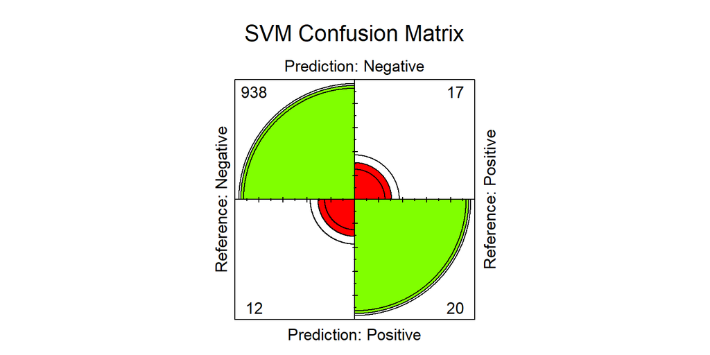

```r
#RF Confusion Matrix 4fold plot
fourfoldplot(SVM_CM$table, col=rainbow(4), main="SVM Confusion Matrix")
```

```r
# Show relative importance of features
# Plot using R base function
plot(varImp(SvmModel, scale=T))
```

[output not shown]

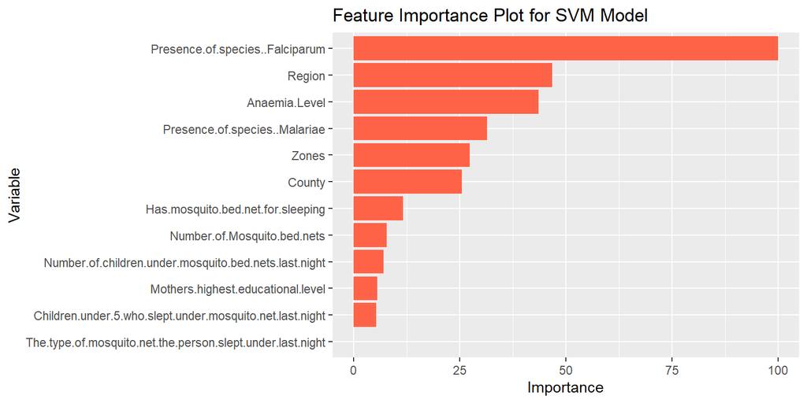

```r
# Alternatively using ggplot function
var_imp <-varImp(SvmModel)
ggplot(var_imp, aes(x = reorder(Variable, Importance), y = importance)) +
  geom_bar(stat = "identity", fill = "tomato") +
  coord_flip() +
  xlab("Variable") +
  ylab("Importance") +
  ggtitle("Feature Importance Plot for SVM Model")
```

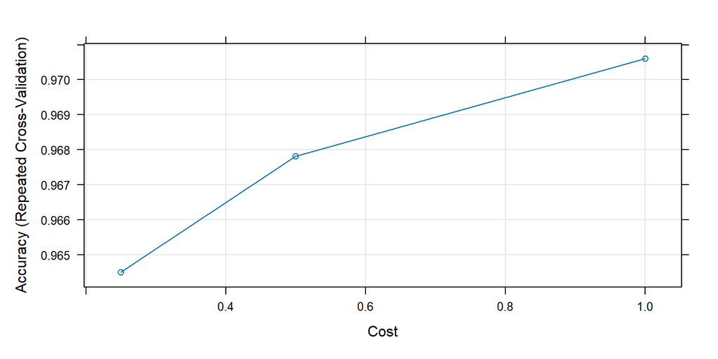

```r
plot(SvmModel)
```

# C:

This parameter is known as the regularization parameter in SVM

This parameter plays a crucial role in determining the trade-off between achieving a low error on the training data and minimizing the model’s complexity, which helps in preventing overfitting.

A smaller C value allows the model to have a smoother decision boundary by permitting some misclassifications on the training data. This can be useful for datasets with noise or outliers.

# sigma (γ):

# Prediction using Trained SVM Model

```r
Svmpred= predict(SvmModel,newdata = test)

# Combine data into a data frame
Ground_truth<- test$Malaria.Test
Predicted <- Svmpred

resultSvm <- data.frame(Ground_truth, Predicted)
resultSvm$Correct <- resultSvm$Ground_truth == resultSvm$Predicted

# Add a column for classification results (correct/incorrect)
resultSVM<- data.frame(test, Svmpred, resultSvm$Correct)
#print(resultSvm,150)
```